Foundations • Digital Logic

# Introduction to Digital Logic

A step-by-step tutorial covering digital logic, analog versus digital signals, the digital design process, and the binary number system.

## 1. Introduction to Digital Logic

**Digital logic** is the study of how electronic systems represent, store, and process information using discrete states. Most digital circuits use two logical states: **0** and **1**. These are called *bits* (binary digits).

### Visual overview: Represent → Store → Process

These are three capabilities of digital systems, not a mandatory execution sequence: circuits can process, store, and exchange bits in different orders.

### What does “discrete states” mean?

A discrete state is one of a limited set of distinct values. Binary digital logic recognizes two logical values: **0 (LOW / false)** and **1 (HIGH / true)**. Physical circuits use voltage ranges to represent these values; LOW is not necessarily exactly 0 volts, and HIGH is not always a particular fixed voltage.

### Interactive example: Security alarm using an AND gate

Imagine an alarm that sounds only when the **door is open** AND the **system is armed**. The door sensor represents one bit; the armed status can be stored in memory; an AND gate processes both bits to determine the alarm output.

Door: System:

Alarm OFF: both inputs must be 1.

| Door (A) | Armed (B) | Alarm (A AND B) |
| --- | --- | --- |
| 0 | 0 | 0 |
| 0 | 1 | 0 |
| 1 | 0 | 0 |
| 1 | 1 | 1 |

**Key idea:** Digital logic is more than binary numbers. It is the design of circuits that represent information, remember states, make decisions, calculate results, and control devices. Processors use large networks of logic circuits, and memory elements retain data for later use.

Digital logic is the foundation of processors, memory, smartphones, digital clocks, traffic controllers, and embedded systems. At the hardware level, transistors form circuits that implement logic operations; larger circuits combine these operations to perform computations and control devices.

### Input

A switch, button, sensor interface, or stored bit provides data.

### Processing

Logic gates and other circuits transform input bits according to rules.

### Output

An LED, display, stored result, or control signal communicates the result.

**Example: A simple light controller.** Suppose a light turns on only when two switches are ON. Represent ON as 1 and OFF as 0. The output is 1 only when both inputs are 1. This is the **AND** operation.

| Switch A | Switch B | Light (A AND B) |
| --- | --- | --- |
| 0 | 0 | 0 |
| 0 | 1 | 0 |
| 1 | 0 | 0 |
| 1 | 1 | 1 |

This table is called a **truth table**: it lists the output for every possible input combination.

Switch A Switch BLight: OFF (0)

A logical 0 or 1 is an abstract state. In physical hardware, it is represented by specified voltage ranges, not necessarily exactly 0 V and 1 V.

### 1.1 Visual explanation: Represent → Store → Process

Digital logic uses **discrete states**: a circuit interprets signals as one of a limited number of values, usually **LOW (0)** or **HIGH (1)**. These are logical meanings; actual electronic voltages occupy technology-dependent ranges.

### Represent

**0 = OFF**  
**1 = ON**

Encode a switch, a sensor reading, or a number as binary digits.

### Store

**Memory / flip-flop**

Retain a 0 or 1 so the circuit can use it later.

### Process

**Logic gates**

Combine bits using AND, OR, and NOT to calculate or make decisions.

### 1.2 Interactive example: Door security alarm

An alarm should sound only if the **door is open** AND the **system is armed**. The door sensor represents the current input; the armed setting can be stored in memory; the AND gate processes both bits.

| Door | Armed | Alarm (AND) |
| --- | --- | --- |
| 0 | 0 | 0 |
| 0 | 1 | 0 |
| 1 | 0 | 0 |
| 1 | 1 | 1 |

**Try it:** Change both switches. The alarm becomes 1 only when both inputs are 1.

**Big picture:** Digital logic is more than writing numbers in binary. It designs electronic systems that **represent data, remember states, perform calculations, and make control decisions**. Examples include computers, calculators, memory chips, and traffic lights.

## 2. From Temperature to Signals: Analog vs. Digital

Before learning digital logic, we need to understand how a system obtains information about the world. We will begin with a familiar example—**room temperature**—without assuming any knowledge of electronics.

### 2.1 A physical quantity can change

Imagine observing the temperature of a classroom throughout the day. It might be 18°C in the morning, 24°C at noon, and 29°C in the afternoon. The temperature does not need to jump directly from one reading to the next; it can pass through values in between.

### 2.2 When does a measurement become useful information?

A reading such as **29°C** tells us something about the room. If we want a fan to turn on when the room becomes too warm, a device must first **detect** the temperature and communicate what it detects.

### Visual: From the room to an action

**Room**

Temperature changes

**→**

**Sensor**

Detects temperature

**→**

**Controller**

Checks the reading

**→**

**Fan**

Turns on if too warm

### 2.3 Introducing the idea of a signal

A **signal** is a physical quantity or pattern used to **carry information**. A temperature sensor produces an output that changes in a way that represents the temperature it detects. The controller can use that output to learn about the room. We call that output a **signal**.

Think of a signal as a **messenger**: the temperature is what we want to know; the signal carries a representation of that temperature to another part of the system. We do not need to study how the sensor works internally yet.

**Important distinction:** Temperature is a physical quantity. A sensor's output can be a signal representing temperature. Information is what the receiving system can learn from that signal.

### 2.4 Why are signals important?

Signals allow systems to **detect changes, communicate measurements, make decisions, and control actions**. A thermometer communicates a temperature reading; a phone carries speech; a keyboard communicates which key was pressed. The underlying technology differs, but the shared idea is that information moves from a source to a receiver.

### 2.5 Analog: representing continuous changes

An **analog signal** can vary continuously over a range. For example, a sensor could produce an analog output that follows gradual changes in room temperature. Between two levels, there can be intermediate levels.

### 2.6 Digital: representing distinct states

A **digital signal** uses distinct states. In introductory digital logic, we usually work with two logical states: **0** and **1**. For example, a temperature-control system can communicate a simple decision: **0 = fan OFF** and **1 = fan ON**.

### 2.7 Compare the two approaches

| Question | Analog | Digital |
| --- | --- | --- |
| How is information represented? | Through continuously varying values | Through distinct states or encoded values |
| Temperature example | An output that gradually follows temperature | A numeric reading such as 29°C, encoded as bits |
| Simple control example | Many possible output levels | Fan OFF (0) or ON (1) |

**One subtle point:** A digital thermometer may show 29°C, 29.1°C, or other numeric readings. Digital does *not* mean that all measurements are reduced to only ON and OFF; it means information is encoded using discrete values, ultimately represented by bits.

### 2.8 How this leads to digital logic

Once information is represented with 0s and 1s, digital systems can **store** those values and **process** them using logical rules. For example: if the measured temperature is above a chosen threshold, output 1 (fan ON); otherwise, output 0 (fan OFF). This is the starting point for digital logic.

**Remember:** Physical world → Measurement → Signal → Digital representation → Logical decision. Later, we can study the electrical details that make these steps possible.

## 3. Digital Design Overview

**Digital design** is the process of creating hardware systems that perform specified functions using binary signals and logic circuits.

### 3.1 Building blocks

| Component | Purpose | Simple example |
| --- | --- | --- |
| Logic gates | Perform basic Boolean operations | AND, OR, NOT |
| Combinational circuits | Output depends on current inputs | Adder, multiplexer |
| Sequential circuits | Output depends on inputs and stored state | Counter, register |
| Clock | Coordinates many sequential state updates | Processor clock |
| Memory | Stores bits for later use | RAM, registers |

### 3.2 Three fundamental logic gates

| Gate | Expression | When output is 1 |
| --- | --- | --- |
| AND | Y = A · B | Both inputs are 1 |
| OR | Y = A + B | At least one input is 1 |
| NOT | Y = ¬A | Input A is 0 |

In Boolean algebra, the symbol + means OR, not ordinary arithmetic addition. For example, 1 OR 1 = 1.

### 3.3 Typical digital design workflow

1. **Define the problem:** Describe what the circuit should do.
2. **Identify inputs and outputs:** Determine the required signals.
3. **Specify behavior:** Create a truth table, Boolean expression, or state diagram.
4. **Design the circuit:** Select and connect logic gates or higher-level components.
5. **Simulate and verify:** Check the design against expected behavior.
6. **Implement and test:** Build the circuit in hardware or program a configurable device such as an FPGA.

**Worked example: Two-condition safety indicator.** An indicator should turn on when a door is open *or* a temperature alarm is active. Let D = 1 mean door open, T = 1 mean temperature alarm, and Y = 1 mean indicator on. The requirement translates to **Y = D OR T**. Its truth table is 00→0, 01→1, 10→1, 11→1. A single OR gate implements this logical function.

### 3.4 Combinational vs. sequential logic

### Combinational

Same current inputs produce the same output (after propagation delay). No stored history is required.

**Example:** A two-input AND gate.

### Sequential

Stored state can affect the output, so previous events matter.

**Example:** A binary counter increments its stored value on clock edges.

## 4. Binary Number System

Humans commonly use **decimal (base 10)**, with digits 0 through 9. Digital systems commonly use **binary (base 2)**, with digits 0 and 1. The value of each digit depends on its **position**.

### 4.1 Place values

In decimal, 347 = 3×10² + 4×10¹ + 7×10⁰. In binary, each position has a weight that is a power of 2.

| Position | 7 | 6 | 5 | 4 | 3 | 2 | 1 | 0 |
| --- | --- | --- | --- | --- | --- | --- | --- | --- |
| Weight | 128 | 64 | 32 | 16 | 8 | 4 | 2 | 1 |
| Example bits | 0 | 0 | 0 | 0 | 1 | 1 | 0 | 1 |

Thus **1101₂ = 8 + 4 + 0 + 1 = 13₁₀**. The subscripts identify the number base.

### 4.2 Binary to decimal

**Example:** Convert 10110₂ to decimal.

```
Binary digits:  1    0    1    1    0
Place weights: 16    8    4    2    1
Contribution: 16 + 0  + 4  + 2  + 0 = 22
```

Therefore, **10110₂ = 22₁₀**.

### 4.3 Decimal to binary

Repeatedly divide the decimal integer by 2, recording each remainder. Read the remainders from bottom to top.

**Example: Convert 25₁₀ to binary.**

```
25 ÷ 2 = 12 remainder 1
12 ÷ 2 =  6 remainder 0
 6 ÷ 2 =  3 remainder 0
 3 ÷ 2 =  1 remainder 1
 1 ÷ 2 =  0 remainder 1

Read upward: 11001₂
```

Check: 16 + 8 + 1 = 25.

### 4.4 Interactive binary converter

Enter a nonnegative integer (0–65535) or a binary string to see the equivalent representation.

Binary 25₁₀

### 4.5 Bits, bytes, and ranges

One **bit** is a binary digit. A **byte** normally consists of 8 bits. With *n* bits, there are **2ⁿ** distinct bit patterns. If interpreted as an unsigned integer, their values range from 0 to 2ⁿ − 1.

| Bits | Patterns | Unsigned range |
| --- | --- | --- |
| 1 | 2 | 0–1 |
| 4 | 16 | 0–15 |
| 8 | 256 | 0–255 |
| 16 | 65,536 | 0–65,535 |

### 4.6 Binary addition

The basic rules are 0+0=0, 0+1=1, 1+0=1, and 1+1=10₂ (write 0 and carry 1).

**Example: 1011₂ + 0110₂**

```
   1011    (11₁₀)
 + 0110    ( 6₁₀)
 ------
  10001    (17₁₀)
```

As in decimal arithmetic, carries move to the next column, but binary columns have only two possible digit values.

### 4.7 Beyond unsigned integers

A bit pattern does not have a unique meaning by itself. It might represent an unsigned integer, a signed integer, a character, or part of an instruction. Signed integers are commonly encoded using **two's complement**; that topic builds on the binary fundamentals introduced here.

## 5. Practice and Review

Try each question, check the feedback, and revisit the relevant section if needed.

**1. Which statement best describes an analog signal?** It can only represent 0 and 1. It can vary continuously over a range. It always has no noise.

**2. What is 1011₂ in decimal?** 9 10 11

**3. Which is a combinational circuit?** AND gate Clocked counter Register

**4. How many unique patterns can four bits represent?** 8 16 32

**5. What does an ADC do?** Store bits permanently Convert digital codes to analog levels Convert analog signals into digital codes

### Key takeaways

- Digital logic processes discrete logical states, usually 0 and 1.
- Analog signals vary continuously; digital signals use discrete levels.
- Digital design moves from requirements to logic specification, implementation, and verification.
- Combinational circuits depend on present inputs; sequential circuits also have stored state.
- Binary is base 2: each digit's weight is a power of 2.
- An n-bit pattern has 2ⁿ possible combinations.

### Further practice

1. Convert 11101₂ to decimal and verify using place values.
2. Convert 42₁₀ to binary using repeated division.
3. Construct a truth table for a two-input OR gate.
4. Explain why a digital sensor interface might require an ADC.
5. Describe one example each of combinational and sequential logic.

**Show answers**

1. 29₁₀. 2. 101010₂. 3. 00→0, 01→1, 10→1, 11→1. 4. To encode continuously varying sensor voltage as discrete binary values. 5. Example: AND gate (combinational), counter (sequential).

## Visual Summary: Represent, Store, Process

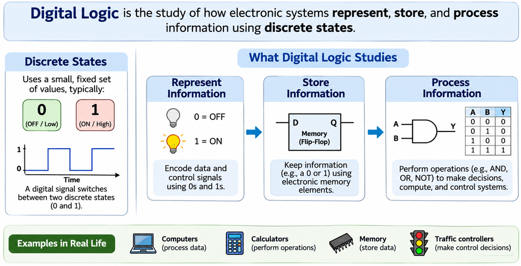